# Mixed Effects Exercises

Repeated Samples and Hierarchial Examples

Sarah Krueger

9/21/2021

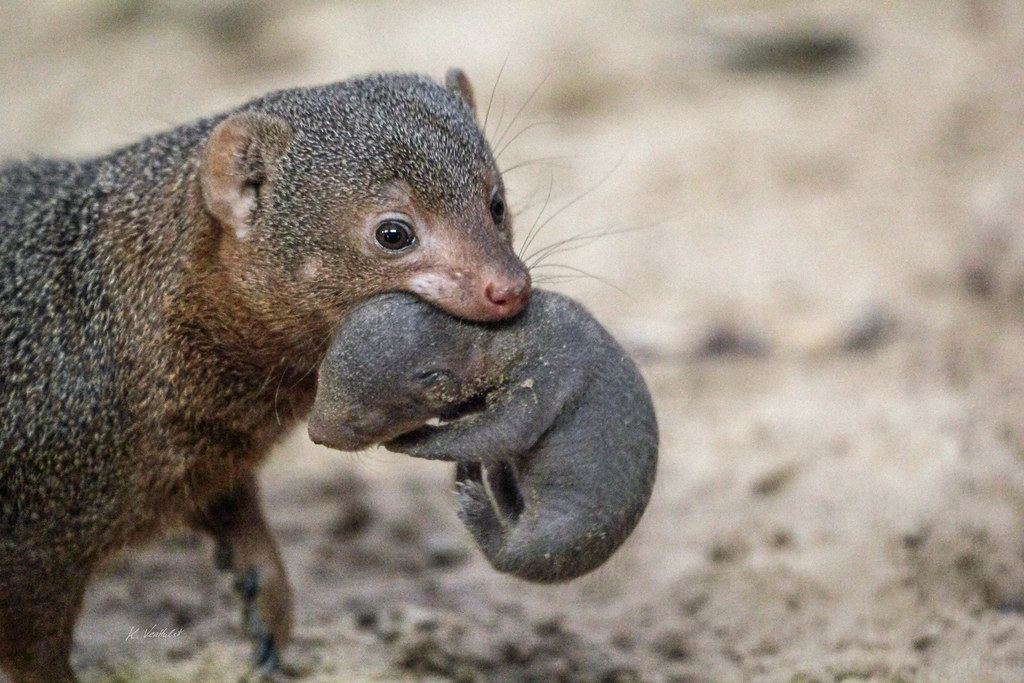

```r
library(tidyverse)
library(lme4)
library(lmerTest)
library(emmeans)
library(ggplot2)
library(performance)
install.packages("ggplot2")
```

I will begin with an example of a “simple repeated measures” mixed model. This study investigated the effects of liter season (spring, fall) and species (meerkat, mongoose) on liter size. A total of 6 meerkats and 6 mongoose were sampled for two seasons.

```r
animals <- read_csv("meerkats.csv")
View(animals)
```

Firstly, I summarized the dataset by species and liter season.

```r
summary <- animals %>%
  group_by(species, liter.season) %>%
  summarise(n = n(),
           mean_liter.size=mean(liter.size),
           se_liter.size=sd(liter.size)/sqrt(n()))

summary
```

```
## # A tibble: 4 x 5
## # Groups:   species [2]
##   species  liter.season     n mean_liter.size se_liter.size
##   <chr>    <chr>        <int>           <dbl>         <dbl>
## 1 meerkat  Fall             6            2.5          0.224
## 2 meerkat  Spring           6            3.67         0.211
## 3 mongoose Fall             6            1.17         0.167
## 4 mongoose Spring           6            2.33         0.333
```

```r
mixed_animals <- lmer(liter.size ~ species*liter.season +(1|id), data = animals)

anova(mixed_animals)
```

```
## Type III Analysis of Variance Table with Satterthwaite's method
##                      Sum Sq Mean Sq NumDF DenDF F value    Pr(>F)
## species              7.2533  7.2533     1    10  25.600 0.0004922 ***
## liter.season         8.1667  8.1667     1    10  28.823 0.0003151 ***
## species:liter.season 0.0000  0.0000     1    10   0.000 1.0000000
## ---
## Signif. codes:  0 '***' 0.001 '**' 0.01 '*' 0.05 '.' 0.1 ' ' 1
```

```r
summary(mixed_animals)
```

```
## Linear mixed model fit by REML. t-tests use Satterthwaite's method [
## lmerModLmerTest]
## Formula: liter.size ~ species * liter.season + (1 | id)
##    Data: animals
##
## REML criterion at convergence: 42.6
##
## Scaled residuals:
##      Min       1Q   Median       3Q      Max
## -2.05402 -0.50411 -0.01252  0.68885  1.11468
##
## Random effects:
##  Groups   Name        Variance Std.Dev.
##  id       (Intercept) 0.06667  0.2582
##  Residual             0.28333  0.5323
## Number of obs: 24, groups:  id, 12
##
## Fixed effects:
##                                      Estimate Std. Error         df t value
## (Intercept)                         2.500e+00  2.415e-01  1.930e+01  10.351
## speciesmongoose                    -1.333e+00  3.416e-01  1.930e+01  -3.904
## liter.seasonSpring                  1.167e+00  3.073e-01  1.000e+01   3.796
## speciesmongoose:liter.seasonSpring  2.961e-15  4.346e-01  1.000e+01   0.000
##                                    Pr(>|t|)
## (Intercept)                        2.56e-09 ***
## speciesmongoose                    0.000932 ***
## liter.seasonSpring                 0.003507 **
## speciesmongoose:liter.seasonSpring 1.000000
## ---
## Signif. codes:  0 '***' 0.001 '**' 0.01 '*' 0.05 '.' 0.1 ' ' 1
##
## Correlation of Fixed Effects:
##             (Intr) spcsmn ltr.sS
## speciesmngs -0.707
## ltr.ssnSprn -0.636  0.450
## spcsmngs:.S  0.450 -0.636 -0.707
```

We can see here that both species and liter season have a significant influence on liter size. We can also see that according to the estimates, mongoose are estimated to have around 1 less offspring per liter than meerkats. For both species, spring allows liter sizes to increase by around 1.

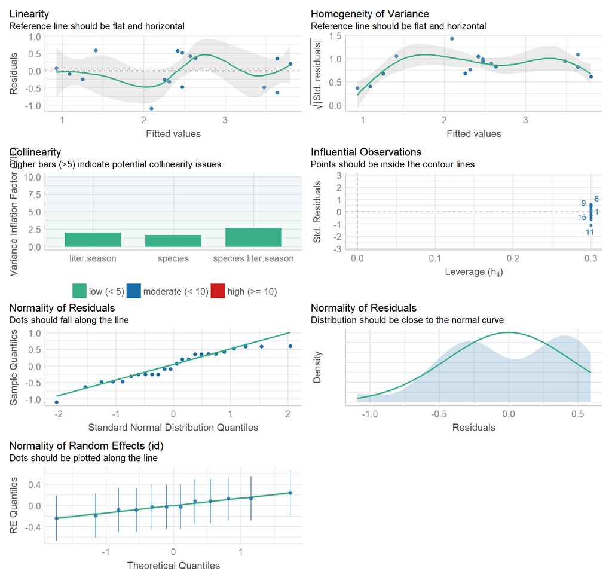

```r
library(see)
performance::check_model(mixed_animals)
```

Next, I calculated the model-adjusted means.

```r
mixed_animals_emm <- emmeans(mixed_animals, "species", "liter.season")
mixed_animals_emm
```

```
## liter.season = Fall:
##  species  emmean    SE   df lower.CL upper.CL
##  meerkat    2.50 0.242 19.3    1.995     3.00
##  mongoose   1.17 0.242 19.3    0.662     1.67
##
## liter.season = Spring:
##  species  emmean    SE   df lower.CL upper.CL
##  meerkat    3.67 0.242 19.3    3.162     4.17
##  mongoose   2.33 0.242 19.3    1.828     2.84
##
## Degrees-of-freedom method: kenward-roger
## Confidence level used: 0.95
```

Because this was a balanced experiement, we can see that the model adjusted means are identical to the raw means but I continued to make a data frame in order to plot.

```r
data_emm <- as.data.frame(summary(mixed_animals_emm))
data_emm
```

```
##    species liter.season   emmean        SE       df  lower.CL upper.CL
## 1  meerkat         Fall 2.500000 0.2415229 19.29978 1.9950176 3.004982
## 2 mongoose         Fall 1.166667 0.2415229 19.29978 0.6616843 1.671649
## 3  meerkat       Spring 3.666667 0.2415229 19.29978 3.1616843 4.171649
## 4 mongoose       Spring 2.333333 0.2415229 19.29978 1.8283509 2.838316
```

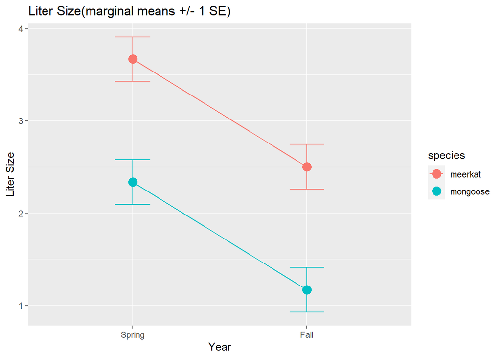

```r
data_emm$liter.season <- factor(data_emm$liter.season, levels = c("Spring", "Fall"))

p<- ggplot(data_emm, aes(x=liter.season, y=emmean, group=species, color=species)) +
  geom_line() +
  geom_point(size=4)+
  geom_errorbar(aes(ymin=emmean-SE, ymax=emmean+SE), width=.2)+
  labs(title="Liter Size(marginal means +/- 1 SE)", x="Year", y = "Liter Size")
p
```

Lastly, I ran a pairwise function to show seasonal contrasts between species and species contrasts between seasons.

```r
pairs(emmeans(mixed_animals, "species", "liter.season"))
```

```
## liter.season = Fall:
##  contrast           estimate    SE   df t.ratio p.value
##  meerkat - mongoose     1.33 0.342 19.3   3.904  0.0009
##
## liter.season = Spring:
##  contrast           estimate    SE   df t.ratio p.value
##  meerkat - mongoose     1.33 0.342 19.3   3.904  0.0009
##
## Degrees-of-freedom method: kenward-roger
```

```r
pairs(emmeans(mixed_animals, "liter.season", "species"))
```

```
## species = meerkat:
##  contrast      estimate    SE df t.ratio p.value
##  Fall - Spring    -1.17 0.307 10  -3.796  0.0035
##
## species = mongoose:
##  contrast      estimate    SE df t.ratio p.value
##  Fall - Spring    -1.17 0.307 10  -3.796  0.0035
##
## Degrees-of-freedom method: kenward-roger
```

```r
emmeans(mixed_animals_emm, specs = pairwise ~ species:liter.season)
```

```
## $emmeans
##  species  liter.season emmean    SE   df lower.CL upper.CL
##  meerkat  Fall           2.50 0.242 19.3    1.995     3.00
##  mongoose Fall           1.17 0.242 19.3    0.662     1.67
##  meerkat  Spring         3.67 0.242 19.3    3.162     4.17
##  mongoose Spring         2.33 0.242 19.3    1.828     2.84
##
## Degrees-of-freedom method: kenward-roger
## Confidence level used: 0.95
##
## $contrasts
##  contrast                         estimate    SE   df t.ratio p.value
##  meerkat Fall - mongoose Fall        1.333 0.342 19.3   3.904  0.0047
##  meerkat Fall - meerkat Spring      -1.167 0.307 10.0  -3.796  0.0155
##  meerkat Fall - mongoose Spring      0.167 0.342 19.3   0.488  0.9609
##  mongoose Fall - meerkat Spring     -2.500 0.342 19.3  -7.319  <.0001
##  mongoose Fall - mongoose Spring    -1.167 0.307 10.0  -3.796  0.0155
##  meerkat Spring - mongoose Spring    1.333 0.342 19.3   3.904  0.0047
##
## Degrees-of-freedom method: kenward-roger
## P value adjustment: tukey method for comparing a family of 4 estimates
```

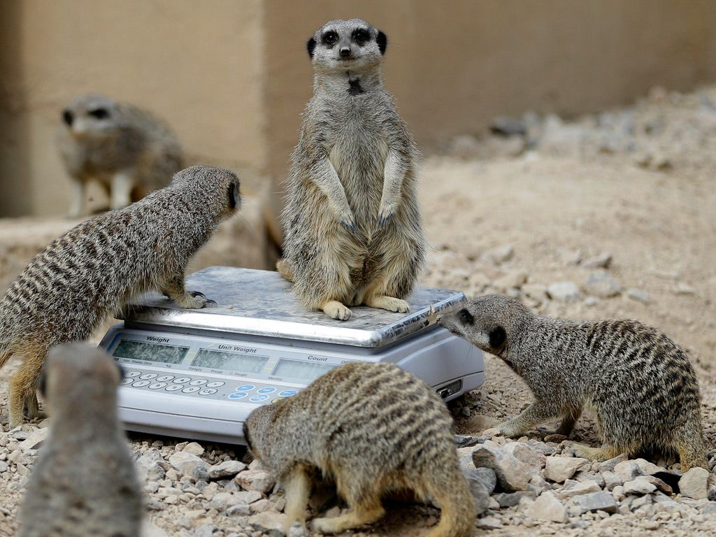

I will now show an example of a “hierarchical” mixed model. This study wanted to determine the relationship between group and parasite richness. Two fecal samples were taken for each individual and parasite richness was recorded for each sample. There were a total of six meerkats in three different groups.

```r
meerkats <- read_csv("meerkats2.csv")
View(meerkats)
```

Firstly, I plotted the raw data.

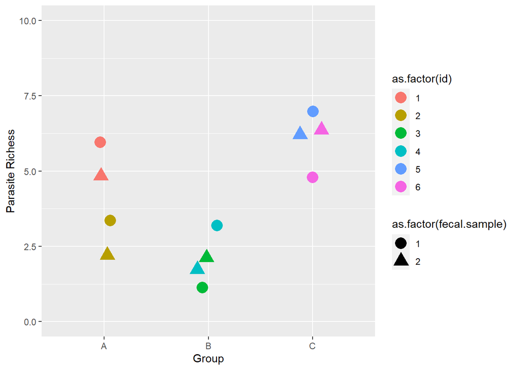

```r
ggplot(meerkats, aes(group, parasite.richness, colour = as.factor(id), shape=as.factor(fecal.sample))) +
  geom_jitter(width =0.15, size=5) +
  ylim(0,10) +
  ylab("Parasite Richess") +
  xlab("Group")
```

```r
mixed_meerkats <- lmer(parasite.richness ~ group + (1|group/id), data = meerkats)
summary(mixed_meerkats)
```

```
## Linear mixed model fit by REML. t-tests use Satterthwaite's method [
## lmerModLmerTest]
## Formula: parasite.richness ~ group + (1 | group/id)
##    Data: meerkats
##
## REML criterion at convergence: 29.4
##
## Scaled residuals:
##     Min      1Q  Median      3Q     Max
## -0.9964 -0.6589  0.0000  0.6589  0.9964
##
## Random effects:
##  Groups   Name        Variance Std.Dev.
##  id:group (Intercept) 1.5834   1.2583
##  group    (Intercept) 0.4873   0.6981
##  Residual             0.5000   0.7071
## Number of obs: 12, groups:  id:group, 6; group, 3
##
## Fixed effects:
##             Estimate Std. Error     df t value Pr(>|t|)
## (Intercept)    4.000      1.185  6.166   3.376   0.0143 *
## groupB        -2.000      1.676  6.166  -1.194   0.2765
## groupC         2.000      1.676  6.166   1.194   0.2765
## ---
## Signif. codes:  0 '***' 0.001 '**' 0.01 '*' 0.05 '.' 0.1 ' ' 1
##
## Correlation of Fixed Effects:
##        (Intr) groupB
## groupB -0.707
## groupC -0.707  0.500
## optimizer (nloptwrap) convergence code: 0 (OK)
## unable to evaluate scaled gradient
##  Hessian is numerically singular: parameters are not uniquely determined
```

For a 1 unit increase in parasite richness for an individual in group A, there is a decrease in two parasites for individuals in group B, and a 2 parasite increase for individuals in group C.

```r
summary <- meerkats %>%
  group_by(group) %>%
  summarise(n = n(),
           mean_parasite.richness=mean(parasite.richness),
           se_parasite.richness=sd(parasite.richness)/sqrt(n()))

summary
```

```
## # A tibble: 3 x 4
##   group     n mean_parasite.richness se_parasite.richness
##   <chr> <int>                  <dbl>                <dbl>
## 1 A         4                      4                0.913
## 2 B         4                      2                0.408
## 3 C         4                      6                0.408
```

Next, I calculated the model-adjusted means.

```r
mixed_meerkats_emm <- emmeans(mixed_meerkats,"group")
mixed_meerkats_emm
```

```
##  group emmean   SE   df lower.CL upper.CL
##  A          4 1.18 7.04    1.201      6.8
##  B          2 1.18 7.04   -0.799      4.8
##  C          6 1.18 7.04    3.201      8.8
##
## Degrees-of-freedom method: kenward-roger
## Confidence level used: 0.95
```

Again, since this was also a balanced experiment, the ajusted means were identical to the raw means. Now, lets plot the means.

```r
data_emm2 <- as.data.frame(summary(mixed_meerkats_emm))

data_emm2
```

```
##   group emmean       SE       df  lower.CL upper.CL
## 1     A      4 1.184889 7.037128  1.201176 6.798824
## 2     B      2 1.184889 7.037128 -0.798824 4.798824
## 3     C      6 1.184889 7.037128  3.201176 8.798824
```

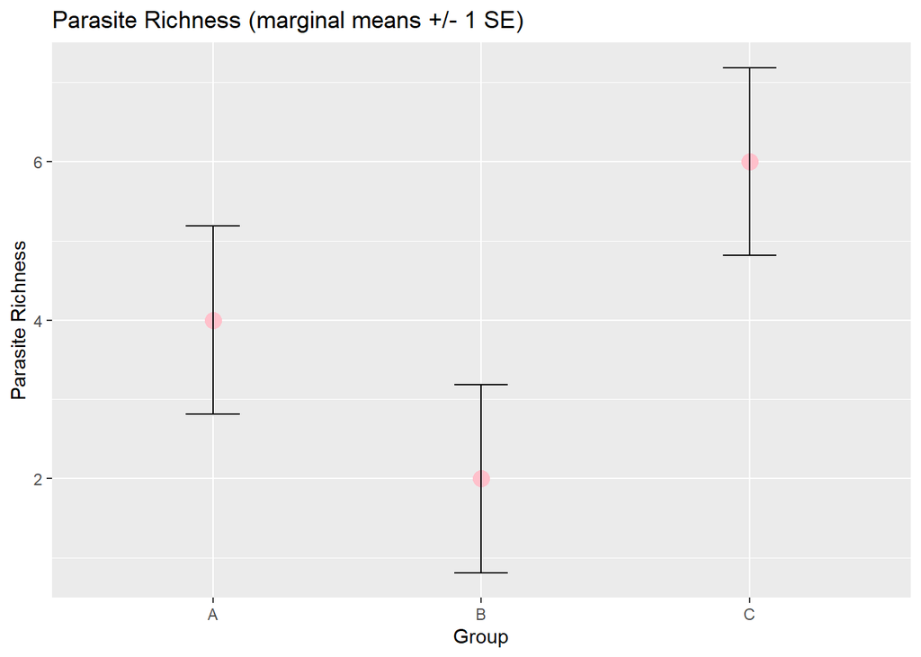

```r
p2 <- ggplot(data_emm2, aes(x=group, y= emmean)) +
  geom_line() +
  geom_point(size=4, color = "pink")+
  geom_errorbar(aes(ymin=emmean-SE, ymax=emmean+SE), width=.2)+
  labs(title="Parasite Richness (marginal means +/- 1 SE)", x="Group", y = "Parasite Richness")
p2
```